# Data wrangling in {tidyr}

Jillian Allison

2022-08-15

#### Read in World Bank data files

```r
wb_indicators <- read_csv(here("data","wb_indicators.csv"), na = c("..", ""))

wb_metadata <- read_csv(here("data","wb_indicators_metadata.csv"))
```

#### Tidy up my data

##### pivot_longer() to get years into a single column

```r
wb_indicators_long <- wb_indicators %>%
  pivot_longer(cols = `2001 [YR2001]`:`2020 [YR2020]`,
               names_to = "year",
               values_to = "value") %>%
  clean_names()
```

##### separate() to clean up the year column

notes: drop_na()– any row where the series name column contains NA gets DROPPED

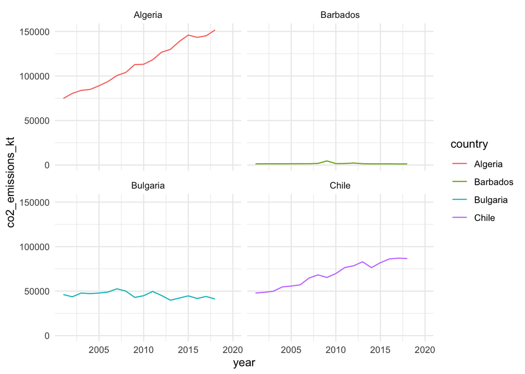

```r
wb_clean <- wb_indicators_long %>%
  separate(col = year,
           into = c("year","year_chr"),
           sep = " ") %>%
  select(-year_chr, -country_code, -series_code) %>% # we don't need the annoying [YR 2001] thing
  mutate(year = as.numeric(year)) %>%
  drop_na('series_name') %>%
  # widen the variables currently trapped in 'series_name' to be spread across multiple columns, and get the values that populated the columns from 'indicator_value'
  pivot_wider(names_from = series_name,
              values_from = value)

names(wb_clean) <- c("country",
                     "year",
                     "access_clean_fuels_pp",
                     "access_electricity_pp",
                     "co2_emissions_kt",
                     "fossil_fuel_consumption_pcttot",
                     "water_stress")

wb_subset <- wb_clean %>%
  filter(country %in% c("Algeria",
                        "Barbados",
                        "Bulgaria",
                        "Chile"))

ggplot(data = wb_subset,
       aes(x = year, y = co2_emissions_kt)) +
  geom_line(aes(color = country)) +
  theme_minimal() +
  facet_wrap(~country)
```

# SELECT() NOTES!!! Columns

Choosing specific columns

```r
ex_14 <- wb_clean %>%
  select(country, year, co2_emissions_kt)
```

Choosing a range of columns

```r
ex_15 <- wb_clean %>%
  select(year:fossil_fuel_consumption_pcttot)
```

Exclude from a range

```r
ex_16 <- wb_clean %>%
  select(year:fossil_fuel_consumption_pcttot, -access_electricity_pp)
```

```r
ex_17 <- wb_clean %>%
  filter(country %in% c("Bolivia","Chile","Mexico")) %>%
  select(country:fossil_fuel_consumption_pcttot)
```

multipurpose use of select() we can rename columns with it! only keeps the columns we referred to, and it renamed them for me, and they’re in the order that i put them . fun and sexy

```r
ex_18 <- wb_clean %>%
  select(year_new = year, emissions = co2_emissions_kt,
         country_name = country)
```

select only columns for country, year, and water_stress

```r
ex_19 <- wb_clean %>%
  select(year, country, water_stress) %>%
  filter(country %in% c("Tanzania","France","Turkey"))
```

### rename()

```r
ex_20 <- wb_clean %>%
  rename(ffcp = fossil_fuel_consumption_pcttot, ws = water_stress)

ex_21 <- wb_clean %>%
  rename(co2_emm_kt = co2_emissions_kt)
```

### mutate(): update an existing column, or add a new one

if you assign a NEW column name, it will add a new column to the end of your data frame. if you assign an existing column name, it will overwrite that column.

add new column related to other existing column

```r
ex_22 <- wb_clean %>%
  mutate(co2_emissions_t = co2_emissions_kt * 1000) %>%
  relocate(co2_emissions_t, .after = co2_emissions_kt)
```

adding a new column with new stuff

```r
ex_23 <- wb_clean %>%
  mutate(yay = "YAY")
```

coercing to a different class!

```r
ex_24 <- wb_clean %>%
  mutate(year = as.character(year))
```

```r
ex_25 <- ex_24 %>%
  mutate(year = as.numeric(year))
```

moving columns around!!

```r
ex_26 <- wb_clean %>%
  relocate(water_stress, .after = year)
```

### more group_by() %>% summarize() examples are in the eds221 notes for lecture 11 and 12 :) bc i like the notes page better and we dont need wb_clean rn

# practice example:

- start from wb_clean
- only keep observations for nicaragua, ecuador, peru, and chile, AND for years greater than 2005
- only keep columns for country, year, and co2_emissions
- add a new column that is co2 emissions converted to megatons
- find the total co2 emissions for the years still in the dataset by country (groupbysummarizesum) in megatons

```r
final_boss_example <- wb_clean %>%
  filter(country %in% c("Nicaragua","Ecuador","Peru","Chile"),
         year > 2005) %>%
  select(country, year, co2_emissions_kt) %>%
  mutate(co2_emissions_mt = co2_emissions_kt / 1000)

summary_final_boss_ex <- final_boss_example %>%
  group_by(country) %>%
  summarize(total_co2_emissions_mt = sum(co2_emissions_mt, na.rm = TRUE))
```